# Tests for Categorical Variables

Mark Dunning. Original materials by Materials by Deepak Parashar, Sarah Dawson and Sarah Vowler

Last modified: 27 Nov 2016

# Tests for categorical variables

# Associations between categorical variables

- All about frequencies!
- Row x Column table (2 x 2 simplest)
- Categorical data
- Look for association (relationship) between row variable and column variable

```
+-----------+-----------------------+-------------------+
|           | Tumour.Did.Not.Shrink | Tumour.Did.Shrink |
+===========+=======================+===================+
| Treatment | 44.00                 | 40.00             |
+-----------+-----------------------+-------------------+
| Placebo   | 24.00                 | 16.00             |
+-----------+-----------------------+-------------------+
```

# Chi-square test

- E.g. Research question: A trial to assess the effectiveness of a new treatment versus a placebo in reducing tumour size in patients with ovarian cancer.

```
+-----------+-----------------------+-------------------+
|           | Tumour.Did.Not.Shrink | Tumour.Did.Shrink |
+===========+=======================+===================+
| Treatment | 44.00                 | 40.00             |
+-----------+-----------------------+-------------------+
| Placebo   | 24.00                 | 16.00             |
+-----------+-----------------------+-------------------+
```

- Is there an association between treatment group and tumour shrinkage
- Null hypothesis, $H_0$: No association
- Alternative hypothesis, $H_1$: Some association
- We can explore these data at:-
  - http://bioinformatics.cruk.cam.ac.uk/apps/stats//contingency-table/

# Chi-square test: calculating expected frequencies

```
+-----------+-----------------------+-------------------+-------+
|           | Tumour.Did.Not.Shrink | Tumour.Did.Shrink | Total |
+===========+=======================+===================+=======+
| Treatment | 44.00                 | 40.00             | 84.00 |
+-----------+-----------------------+-------------------+-------+
| Placebo   | 24.00                 | 16.00             | 40.00 |
+-----------+-----------------------+-------------------+-------+
| Total     | 68.00                 | 56.00             | 68.00 |
+-----------+-----------------------+-------------------+-------+
```

$$E = \frac{row.total \times col.total}{overall.total}$$

- e.g. for row 1, column 1
  $$\frac{84}{124} \times \frac{68}{124} \times 124 = \frac{84\times68}{124} = 46.1$$

# Chi-square test: calculating the chi-square statistic

*Observed frequencies:*

```
+-----------+-----------------------+-------------------+
|           | Tumour.Did.Not.Shrink | Tumour.Did.Shrink |
+===========+=======================+===================+
| Treatment | 44.00                 | 40.00             |
+-----------+-----------------------+-------------------+
| Placebo   | 24.00                 | 16.00             |
+-----------+-----------------------+-------------------+
```

*Expected frequencies:*

```
+-------+-------+
| 46.06 | 37.94 |
+-------+-------+
| 21.94 | 18.06 |
+-------+-------+
```

$$\chi^2_1 = \frac{(44-46.06)^2}{46.06} + \frac{(40-37.94)^2}{37.94} + \frac{(24-21.94)^2}{21.94} + \frac{(16-18.06)^2}{18.06} = 0.63$$

# Chi-square test

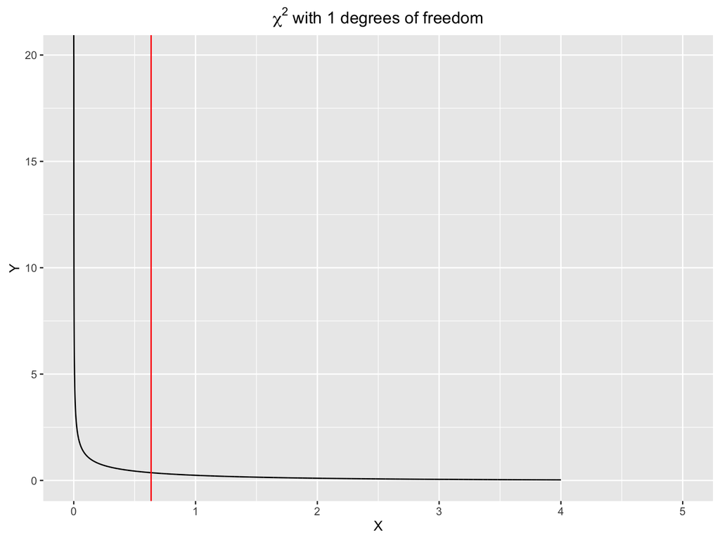

*Do not reject $H_0$ (No evidence of an association between treatment group and tumour shrinkage)*

# Limitations of the chi-square test

- In general, a Chi-square test is appropriate when:
  - at least 80% of the cells have an expected frequency of 5 or greater
  - none of the cells have an expected frequency less than 1
- If these conditions aren’t met, *Fisher’s exact test* should be used.
  - no statistic is computed; an exact probability is calculated

# Same question, smaller sample size

- e.g. Research question: Is there an association between treatment group and tumour shrinkage?

```
+-----------+-----------------------+-------------------+-------+
|           | Tumour.Did.Not.Shrink | Tumour.Did.Shrink | Total |
+===========+=======================+===================+=======+
| Treatment | 8.00                  | 3.00              | 11.00 |
+-----------+-----------------------+-------------------+-------+
| Placebo   | 9.00                  | 4.00              | 13.00 |
+-----------+-----------------------+-------------------+-------+
| Total     | 17.00                 | 7.00              | 17.00 |
+-----------+-----------------------+-------------------+-------+
```

- Null hypothesis: $H_0$: No association
- Alternative hypothesis: $H_1$: Some association

# Fishers’ exact test; results

Observed frequencies:-

```
+-----------+-----------------------+-------------------+-------+
|           | Tumour.Did.Not.Shrink | Tumour.Did.Shrink | Total |
+===========+=======================+===================+=======+
| Treatment | 8.00                  | 3.00              | 11.00 |
+-----------+-----------------------+-------------------+-------+
| Placebo   | 9.00                  | 4.00              | 13.00 |
+-----------+-----------------------+-------------------+-------+
| Total     | 17.00                 | 7.00              | 17.00 |
+-----------+-----------------------+-------------------+-------+
```

Expected frequencies:-

```
+------+------+
| 7.80 | 3.20 |
+------+------+
| 9.20 | 3.80 |
+------+------+
```

- Test statistic: N/A
- P-value 1
- Interpretation: *Do not reject* $H_0$ (No evidence of an association between treatment group and tumour shrinkage)

# Chi-square test for trend

- e.g. Research question: Is there a linear association between tumour grade and the incidence of tumour shrinkage

```
+---------+-----------------------+-------------------+-------+
|         | Tumour.Did.Not.Shrink | Tumour.Did.Shrink | Total |
+=========+=======================+===================+=======+
| Grade 1 | 18.00                 | 5.00              | 23.00 |
+---------+-----------------------+-------------------+-------+
| Grade 2 | 15.00                 | 14.00             | 29.00 |
+---------+-----------------------+-------------------+-------+
| Grade 3 | 11.00                 | 21.00             | 32.00 |
+---------+-----------------------+-------------------+-------+
| Total   | 44.00                 | 40.00             | 44.00 |
+---------+-----------------------+-------------------+-------+
```

- Null hypothesis: $H_0$: No linear association
- Alternative hypothesis: $H_1$: Some linear association

# Expected frequencies

```
+---------+-----------------------+-------------------+-------+
|         | Tumour.Did.Not.Shrink | Tumour.Did.Shrink | Total |
+=========+=======================+===================+=======+
| Grade 1 | 18.00                 | 5.00              | 23.00 |
+---------+-----------------------+-------------------+-------+
| Grade 2 | 15.00                 | 14.00             | 29.00 |
+---------+-----------------------+-------------------+-------+
| Grade 3 | 11.00                 | 21.00             | 32.00 |
+---------+-----------------------+-------------------+-------+
| Total   | 44.00                 | 40.00             | 44.00 |
+---------+-----------------------+-------------------+-------+
```

Expected

```
        Tumour.Did.Not.Shrink Tumour.Did.Shrink
Grade 1                  12.0              11.0
Grade 2                  15.2              13.8
Grade 3                  16.8              15.2
```

# CHi-square test for trend

[figure not shown]

# Chi-square test for trend - Results

Test statistic:
$$\chi_1^2 = 10.18$$
df = 1 P-value = 0.001

Conclusion:- Reject $H`_0$ (evidence of a linear association between tumour grade and tumour shrinkage)

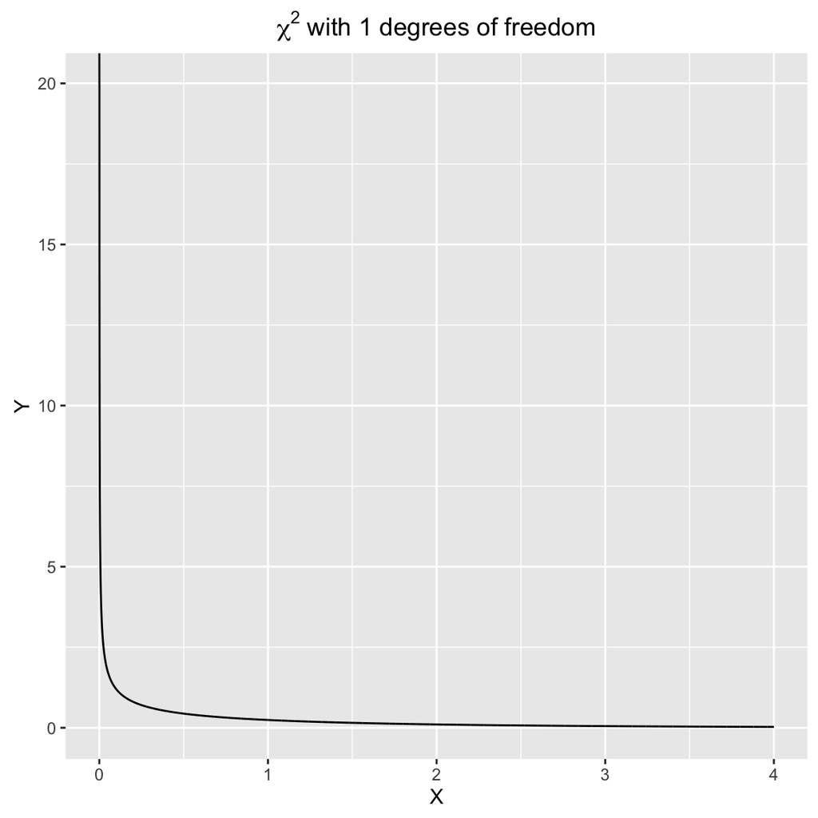

# Summary - Categorical variables

- Chi-square test
  - Use when we have two categorical variables, each with two or more levels, and our expected frequencies are not too small.
- Fishers exact test
  - Use when we have two categorical variables, each with two levels, and our expected frequencies are small.
- *Exercise*
  - Complete “Tests for categorical variables” section of practical

# Small group Exercise

- In groups of 3 /4 you are going to explore several example datasets
- Each dataset has a brief explanation
  - You have to decide what test is appropriate?
  - Parametric / Non-parametric?
  - Paired? Independent?
  - Two-sided?
- Record your observations here:- https://public.etherpad-mozilla.org/p/2016-11-28-intro-to-stats

# References

- Essential Medical Statistics, Betty Kirkwood and Jonathan Sterne, Wiley-Blackwell, 2nd Edition 2003.
- Practical Statistics for Medical Research, Douglas G. Altman, Chapman & Hall / CRC, 1999.
- Ten Simple Rules for Effective Statistical Practice, Robert E. Kass, Brian S. Caffo, Marie Davidian, Xio-Li Meng, Bin Yu, Nancy Reid http://journals.plos.org/ploscompbiol/article?id=10.1371/journal.pcbi.1004961

# Finally

- Course Materials:-
  - http://tiny.cc/crukStats
- Course Feedback:-
  - http://tinyurl.com/stats-nov18